# Praca domowa 2

Igor Ptak

## Dane

Dane wykorzystane w Pracy domowej 2 dotyczą wyników egzaminów z 3 umiejętności: czytania, pisania i operacji matematycznych. Dodatkowo dostępne są podstawowe informacje o studentach i ich rodzicach. Opis wszystkich kolumn znajduje się również w pliku `README.md`.

| Zmienna | Opis |
| --- | --- |
| **gender** | płeć |
| **race.ethnicity** | pochodzenie etniczne |
| **parental.level.of.education** | wykształcenie rodziców |
| **lunch** | jaki obiad jedli uczniowie w dniu egzaminu |
| **test.preparation.course** | czy uczeń odbył kurs przygotowujący |
| **math.score** | wynik egzaminu z matematyki |
| **reading.score** | wynik egzaminu z czytania |
| **writing.score** | wynik egzaminu z pisania |

## Zadanie 1

Jak wyglądają rozkłady wyników uczniów z trzech przedmiotów (matematyka, czytanie, pisanie)?

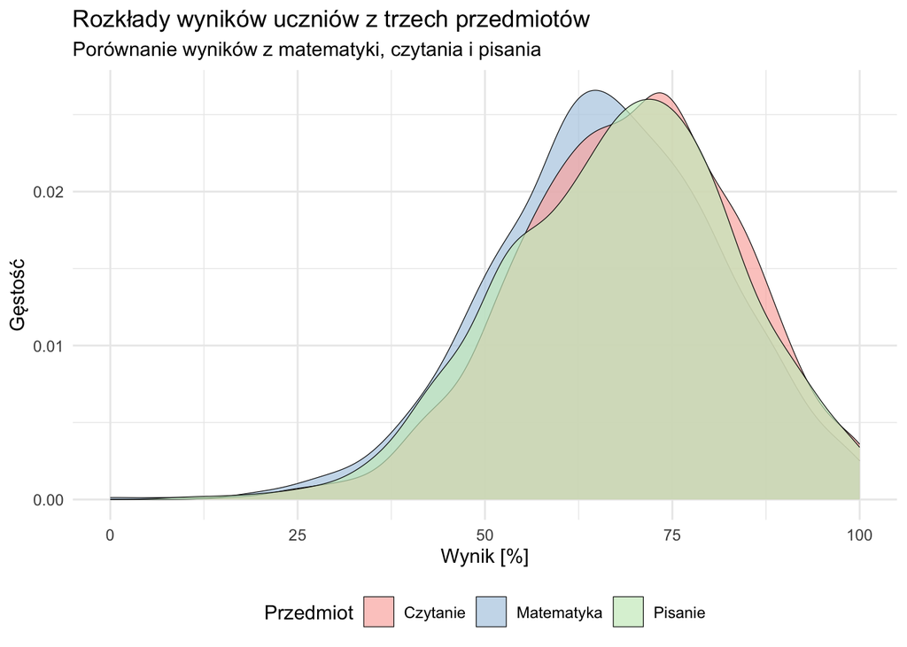

```r
# Tu umieść kod do wygenerowania odpowiedzi do zadania.
ggplot(df) +
  geom_density(aes(x = math.score, fill = "Matematyka"),
               alpha = 0.7, color = "black", linewidth = 0.2) +
  geom_density(aes(x = reading.score, fill = "Czytanie"),
               alpha = 0.7, color = "black", linewidth = 0.2) +
  geom_density(aes(x = writing.score, fill = "Pisanie"),
               alpha = 0.7, color = "black", linewidth = 0.2) +

  labs(title = "Rozkłady wyników uczniów z trzech przedmiotów",
       subtitle = "Porównanie wyników z matematyki, czytania i pisania",
       x = "Wynik [%]",
       y = "Gęstość",
       fill = "Przedmiot") +
  theme_minimal() +
  scale_fill_brewer(palette = "Pastel1") +
  theme(legend.position = "bottom")
```

**Komentarz:** Rozkłady wyników z czytania i pisania są bardzo do siebie podobne i skupione wokół wyższych wartości (ok. 70-80 punktów). Rozkład wyników z matematyki jest przesunięty w stronę niższych wartości, co wskazuje, że uczniowie radzili sobie z tym przedmiotem słabiej niż z pozostałymi dwoma.

## Zadanie 2

Czy istnieje zauważalna różnica w wynikach między uczniami i uczennicami?

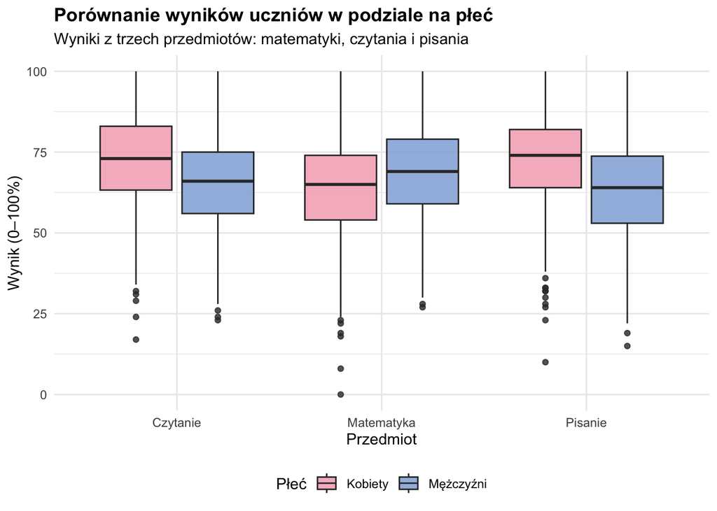

```r
# Tu umieść kod do wygenerowania odpowiedzi do zadania.
df_long <- df %>%
  pivot_longer(
    cols = c(math.score, reading.score, writing.score),
    names_to = "subject",
    values_to = "score"
  ) %>%
  mutate(
    subject = recode(subject,
                     "math.score" = "Matematyka",
                     "reading.score" = "Czytanie",
                     "writing.score" = "Pisanie"),
    gender = recode(gender,
                    "female" = "Kobiety",
                    "male" = "Mężczyźni")
  )

ggplot(df_long, aes(x = subject, y = score, fill = gender)) +
  geom_boxplot(alpha = 0.8, width = 0.7, position = position_dodge(0.8)) +
  labs(
    title = "Porównanie wyników uczniów w podziale na płeć",
    subtitle = "Wyniki z trzech przedmiotów: matematyki, czytania i pisania",
    x = "Przedmiot",
    y = "Wynik (0–100%)",
    fill = "Płeć"
  ) +
  scale_fill_manual(values = c("#F4A7B9", "#89A9D9")) +
  theme_minimal() +
  theme(
    legend.position = "bottom",
    plot.title = element_text(face = "bold")
  )
```

**Komentarz:** Tak, istnieje bardzo zauważalna różnica w wynikach między płciami, która jest zależna od przedmiotu. Uczniowie (mężczyźni) osiągają statystycznie lepsze wyniki z matematyki, natomiast uczennice (kobiety) wyższe z czytania oraz z pisania.

## Zadanie 3

Czy uczniowie, którzy ukończyli kurs przygotowawczy, osiągają lepsze wyniki niż pozostali?

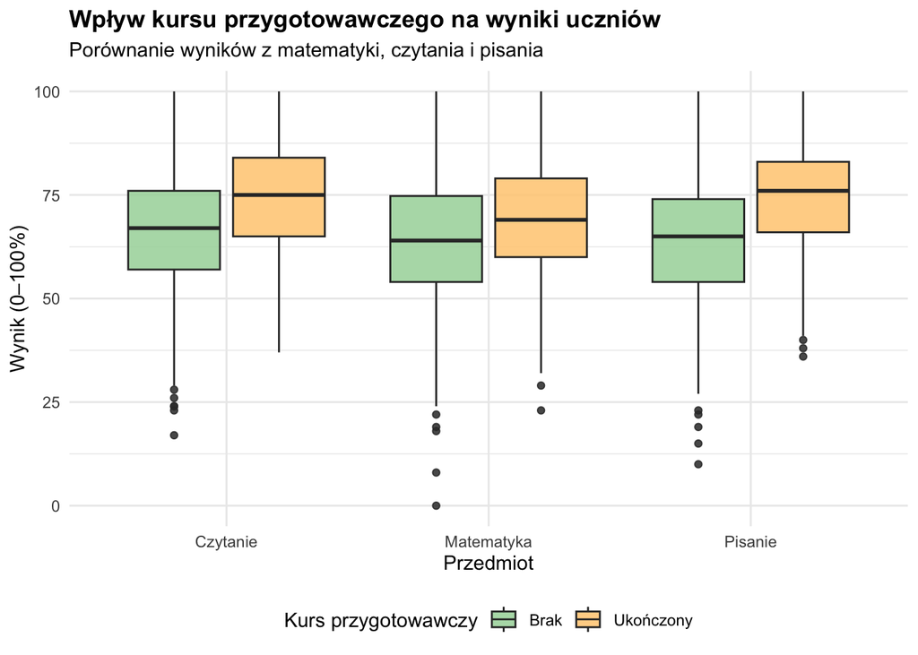

```r
# Tu umieść kod do wygenerowania odpowiedzi do zadania.
df_long <- df %>%
  pivot_longer(
    cols = c(math.score, reading.score, writing.score),
    names_to = "subject",
    values_to = "score"
  ) %>%
  mutate(
    subject = recode(subject,
                     "math.score" = "Matematyka",
                     "reading.score" = "Czytanie",
                     "writing.score" = "Pisanie"),
    test.preparation.course = recode(test.preparation.course,
                                     "completed" = "Ukończony",
                                     "none" = "Brak")
  )

ggplot(df_long, aes(x = subject, y = score, fill = test.preparation.course)) +
  geom_boxplot(alpha = 0.85, width = 0.7, position = position_dodge(0.8)) +
  scale_fill_manual(values = c("#A5D6A7", "#FFCC80")) +
  labs(
    title = "Wpływ kursu przygotowawczego na wyniki uczniów",
    subtitle = "Porównanie wyników z matematyki, czytania i pisania",
    x = "Przedmiot",
    y = "Wynik (0–100%)",
    fill = "Kurs przygotowawczy"
  ) +
  theme_minimal() +
  theme(
    legend.position = "bottom",
    plot.title = element_text(face = "bold")
  )
```

**Komentarz:** Uczniowie, którzy ukończyli kurs przygotowawczy, osiągają lepsze wyniki w każdym z trzech przedmiotów. Różnice są najbardziej widoczne w czytaniu i pisaniu, gdzie mediany wyników są wyraźnie wyższe niż u osób bez kursu. W przypadku matematyki różnica jest mniejsza, ale nadal widoczna. Kurs przygotowawczy można więc uznać za korzystny, zwłaszcza w zakresie umiejętności językowych.

## Zadanie 4

Jaki jest związek między poziomem wykształcenia rodziców a średnimi wynikami uczniów?

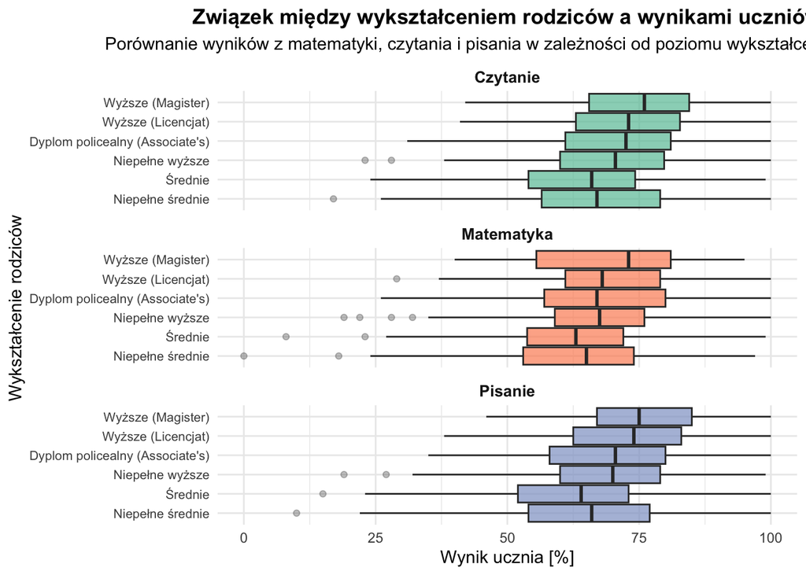

```r
edu_levels_order_en <- c("master's degree",
                         "bachelor's degree",
                         "associate's degree",
                         "some college",
                         "high school",
                         "some high school")

edu_levels_labels_pl <- c("Wyższe (Magister)",
                          "Wyższe (Licencjat)",
                          "Dyplom policealny (Associate's)",
                          "Niepełne wyższe",
                          "Średnie",
                          "Niepełne średnie")

df_long <- df %>%
  pivot_longer(
    cols = c(math.score, reading.score, writing.score),
    names_to = "subject",
    values_to = "score"
  ) %>%
  mutate(
    subject = recode(subject,
                     "math.score" = "Matematyka",
                     "reading.score" = "Czytanie",
                     "writing.score" = "Pisanie"),
    parental.level.of.education = factor(
      parental.level.of.education,
      levels = rev(edu_levels_order_en),
      labels = rev(edu_levels_labels_pl)
    )
  )

ggplot(df_long, aes(x = parental.level.of.education, y = score, fill = subject)) +
  geom_boxplot(alpha = 0.7, width = 0.9, outlier.alpha = 0.3) +
  coord_flip() +
  facet_wrap(~subject, ncol = 1) +
  scale_fill_brewer(palette = "Set2") +
  labs(
    title = "Związek między wykształceniem rodziców a wynikami uczniów",
    subtitle = "Porównanie wyników z matematyki, czytania i pisania w zależności od poziomu wykształcenia rodziców",
    x = "Wykształcenie rodziców",
    y = "Wynik ucznia [%]",
    fill = "Przedmiot"
  ) +
  theme_minimal() +
  theme(
    legend.position = "none",
    strip.text = element_text(face = "bold", size = 10),
    plot.title = element_text(face = "bold", hjust = 0.5),
    axis.text.y = element_text(size = 8),
    plot.subtitle = element_text(hjust = 0.5)
  )
```

**Komentarz:** Wykres pokazuje, że wraz ze wzrostem poziomu wykształcenia rodziców rosną średnie wyniki uczniów. Trend ten widoczny jest we wszystkich trzech przedmiotach.

Matematyka: różnice między grupami są umiarkowane, ale widoczne.

Wniosek: wyższe wykształcenie rodziców sprzyja lepszym wynikom dzieci, szczególnie w umiejętnościach językowych.

## Zadanie 5

Czy płeć i wykształcenie rodzica wpływa na wynik z matematyki?

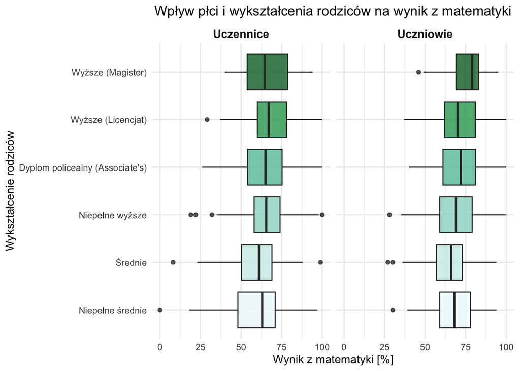

```r
# Tu umieść kod do wygenerowania odpowiedzi do zadania.

# Tu umieść kod do wygenerowania odpowiedzi do zadania.
edu_levels_order_en <- c("master's degree",
                         "bachelor's degree",
                         "associate's degree",
                         "some college",
                         "high school",
                         "some high school")

edu_levels_labels_pl <- c("Wyższe (Magister)",
                          "Wyższe (Licencjat)",
                          "Dyplom policealny (Associate's)",
                          "Niepełne wyższe",
                          "Średnie",
                          "Niepełne średnie")

df_zad5 <- df %>%
  mutate(parental.level.of.education = factor(parental.level.of.education,
                                              levels = rev(edu_levels_order_en),
                                              labels = rev(edu_levels_labels_pl)))

gender_labels <- c("female" = "Uczennice", "male" = "Uczniowie")

ggplot(df_zad5, aes(x = parental.level.of.education, y = math.score)) +

  geom_boxplot(aes(fill = parental.level.of.education),
               alpha = 0.8,
               show.legend = FALSE) +

  facet_wrap(~ gender, labeller = as_labeller(gender_labels)) +

  coord_flip() +

  labs(title = "Wpływ płci i wykształcenia rodziców na wynik z matematyki",
       x = "Wykształcenie rodziców",
       y = "Wynik z matematyki [%]") +

  theme_minimal() +
  scale_fill_brewer(palette = "BuGn") +

  theme(
    plot.title = element_text(hjust = 0.5),
    plot.subtitle = element_text(hjust = 0.5),
    strip.text = element_text(size = 11, face = "bold")
  )
```

Płeć również ma znaczenie – uczniowie (mężczyźni) osiągają lepsze wyniki z matematyki niż uczennice, nawet przy tym samym poziomie wykształcenia rodziców.

## Zadanie 6

Czy istnieje zależność między wynikami z matematyki a wynikami z czytania lub pisania?

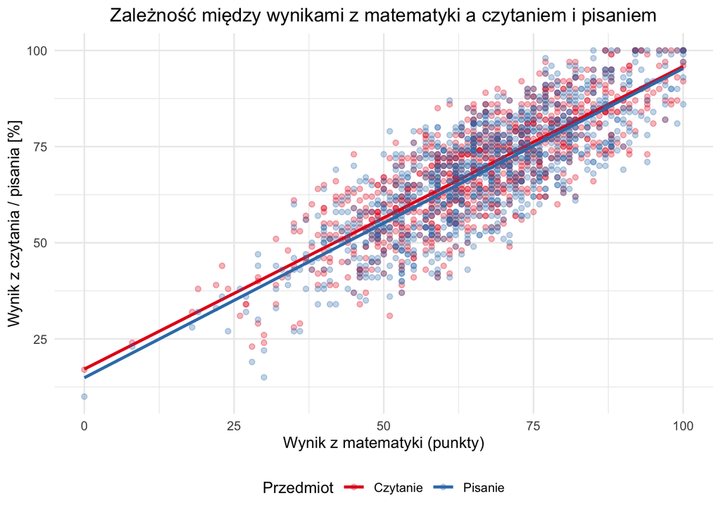

```r
# Tu umieść kod do wygenerowania odpowiedzi do zadania.
# Tworzymy wykres, mapując 'x' do wyniku z matematyki
ggplot(df, aes(x = math.score)) +

  # Warstwa dla CZYTANIA (punkty)
  geom_point(aes(y = reading.score, color = "Czytanie"),
             alpha = 0.3) + # Przezroczystość, aby poradzić sobie z nadmiarowością punktów

  # Warstwa dla CZYTANIA (linia trendu)
  geom_smooth(aes(y = reading.score, color = "Czytanie"),
              method = "lm", # "lm" to model liniowy (linia prosta)
              se = FALSE,     # Ukrywamy przedział ufności (szary cień)
              linewidth = 1) +

  # Warstwa dla PISANIA (punkty)
  geom_point(aes(y = writing.score, color = "Pisanie"),
             alpha = 0.3) +

  # Warstwa dla PISANIA (linia trendu)
  geom_smooth(aes(y = writing.score, color = "Pisanie"),
              method = "lm",
              se = FALSE,
              linewidth = 1) +

  labs(title = "Zależność między wynikami z matematyki a czytaniem i pisaniem",
       x = "Wynik z matematyki (punkty)",
       y = "Wynik z czytania / pisania [%]",
       color = "Przedmiot") +

  theme_minimal() +
  scale_color_brewer(palette = "Set1") + # Użycie wyraźnej palety kolorów
  theme(
    plot.title = element_text(hjust = 0.5), # Wyśrodkowanie tytułu
    legend.position = "bottom"
  )
```

**Komentarz:** Tak, istnieje silna, pozytywna zależność między wynikami z matematyki a wynikami z czytania oraz pisania. Uczniowie osiągający wysokie wyniki w jednej z tych dziedzin, zazwyczaj osiągają wysokie wyniki również w pozostałych.